# CIND820_FinalResult (2)

```python
# Import the necessary libraries
import pandas as pd
import numpy as np
import matplotlib.pyplot as plt
import seaborn as sns
import os

# Load the dataset from Colab
from google.colab import files
uploaded = files.upload()
```

Upload widget is only available when the cell has been executed in the current browser session. Please rerun this cell to enable.

```
Saving Health Dataset5.csv to Health Dataset5.csv
```

```python
# Read the dataset
df = pd.read_csv('Health Dataset5.csv')

# Summary for general info
print("Summary for general info:")
df.info()

# Summary for descriptive statistics for numeric columns
print("\nSummary for descriptive statistics for numeric columns:")
print(df.describe())
```

```
Summary for general info:
<class 'pandas.core.frame.DataFrame'>
RangeIndex: 17645 entries, 0 to 17644
Data columns (total 18 columns):
 #   Column                         Non-Null Count  Dtype
---  ------                         --------------  -----
 0   Country                        17645 non-null  object
 1   Year                           17645 non-null  int64
 2   Cost of a healthy diet         17504 non-null  float64
 3   Income                         17525 non-null  float64
 4   Inflation                      17590 non-null  float64
 5   Child mortality rate           17645 non-null  float64
 6   Unemployment Rate              17604 non-null  float64
 7   Life expectancy                17645 non-null  float64
 8   Incomplete tertiary education  17645 non-null  float64
 9   Gini coefficient               17525 non-null  float64
 10  Diabetes                       17615 non-null  float64
 11  BMI (female)                   17620 non-null  float64
 12  Cardiovascular diseases        17595 non-null  float64
 13  BMI (male)                     17620 non-null  float64
 14  Sex ratio                      17645 non-null  float64
 15  GDP                            17595 non-null  float64
 16  Median age                     17645 non-null  float64
 17  CPI                            17591 non-null  float64
dtypes: float64(16), int64(1), object(1)
memory usage: 2.4+ MB

Summary for descriptive statistics for numeric columns:
               Year  Cost of a healthy diet        Income     Inflation  \
count  17645.000000            17504.000000  17525.000000  17590.000000
mean    1986.538339                3.696326     19.513999     16.780677
std       21.362973                0.791526     20.807002    228.759581
min     1950.000000                1.607861      1.007993    -17.640425
25%     1968.000000                3.185103      5.017792      2.936995
50%     1987.000000                3.592499     10.724820      5.186481
75%     2005.000000                4.148040     24.844337      9.362823
max     2023.000000                6.259097     93.327800  23773.130000

       Child mortality rate  Unemployment Rate  Life expectancy  \
count          17645.000000       17604.000000     17645.000000
```

[output cut: 22 more lines]

```
min       16.399592                 0.000928     17.634594     71.428570
25%       23.734100                 0.298413     22.647126    102.623130
50%       25.738728                 1.456723     25.223253    104.245140
75%       27.310578                 5.421141     26.793611    105.633804
max       35.224032              1921.131800     33.556548    200.000000

                GDP    Median age           CPI
count  1.759500e+04  17645.000000  1.759100e+04
mean   2.925977e+12     23.856445  2.113603e+02
std    1.594833e+13      8.100374  1.230694e+03
min    2.625572e+07     12.617000  3.550000e-14
25%    1.665892e+10     17.196000  6.461704e+01
50%    7.804498e+10     20.919000  1.214129e+02
75%    5.070000e+11     29.672000  1.574048e+02
max    1.670000e+14     62.417000  3.879656e+04
```

# **Data Cleaning**

## Identify and Handle Duplicates

```python
# Identify duplicates
print(f"Number of duplicate rows: {df.duplicated().sum()}")

# Inspect duplicate rows
print(df[df.duplicated(keep=False)])

# Drop rows where all values are NaN (completely blank rows)
#df.dropna(how='all', inplace=True)
```

```
Number of duplicate rows: 0
Empty DataFrame
Columns: [Country, Year, Cost of a healthy diet, Income, Inflation, Child mortality rate, Unemployment Rate, Life expectancy, Incomplete tertiary education, Gini coefficient, Diabetes, BMI (female), Cardiovascular diseases, BMI (male), Sex ratio, GDP, Median age, CPI]
Index: []
```

```python
# Drop rows where all values are NaN (all blank rows)
df.dropna(how='all', inplace=True)

# Drop duplicate rows (keep first occurrence)
df.drop_duplicates(inplace=True)

# Check remaining duplicates
print(f"Duplicates after dropping: {df.duplicated().sum()}")
```

```
Duplicates after dropping: 0
```

After removed the blank rows and verified there is no duplicates in this dataset.

## Identify Missing Data

```python
# Identify number of missing values per column

print("\nCount of missing values:")
print(df.isnull().sum())
```

```
Count of missing values:
Country                            0
Year                               0
Cost of a healthy diet           141
Income                           120
Inflation                         55
Child mortality rate               0
Unemployment Rate                 41
Life expectancy                    0
Incomplete tertiary education      0
Gini coefficient                 120
Diabetes                          30
BMI (female)                      25
Cardiovascular diseases           50
BMI (male)                        25
Sex ratio                          0
GDP                               50
Median age                         0
CPI                               54
dtype: int64
```

# QQ Plot of Residuals, Residuals vs. Fitted Values Plot

This plot helps check for the assumptions of linearity and constant variance for a linear regression model.

If curved residual patterns, it indicates that the relationship between predictors and the target is not linear that a linear model may be inappropriate.

The funnel shapes increasing or decreasing spread, which means the variance of the residuals is not constant across all fitted values. This violates one of the key assumptions of linear regression and can lead to inefficient and biased estimates

```
Modeling for: Life expectancy
```

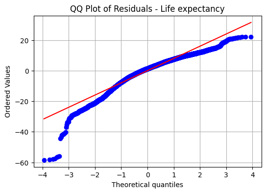

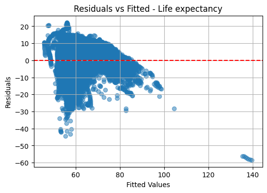

```
Residuals Summary:
  Mean: -0.0000
  Std Dev: 8.2276
  Skewness: -1.0599
  Kurtosis: 1.9206
  Shapiro-Wilk: Statistic=0.9420, p-value=0.0000
 Residuals deviate from normality.

Modeling for: Cardiovascular diseases
```

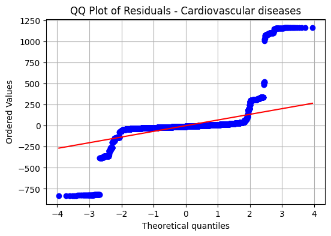

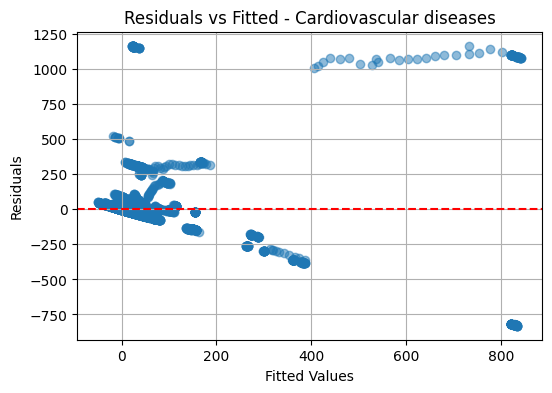

```
Residuals Summary:
  Mean: 0.0001
  Std Dev: 120.4087
  Skewness: 4.6438
  Kurtosis: 59.1114
  Shapiro-Wilk: Statistic=0.3134, p-value=0.0000
 Residuals deviate from normality.

Modeling for: Diabetes
```

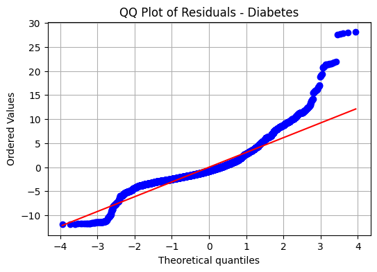

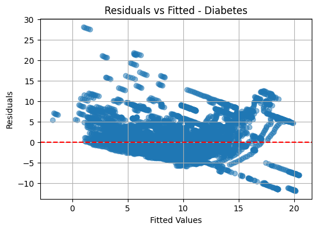

```
Residuals Summary:
  Mean: -0.0000
  Std Dev: 3.2707
  Skewness: 1.4892
  Kurtosis: 5.4749
  Shapiro-Wilk: Statistic=0.8798, p-value=0.0000
 Residuals deviate from normality.
```

```python
import statsmodels.api as sm
import matplotlib.pyplot as plt
from scipy import stats

# List of predictors (make sure column names match exactly in your dataframe)
features = [
    'Income', 'GDP', 'CPI', 'Sex ratio',
    'BMI (female)', 'Cost of a healthy diet', 'Inflation',
    'Incomplete tertiary education', 'Gini coefficient', 'Median age'
]

# Loop through each target variable
for target in ['Life expectancy', 'Cardiovascular diseases', 'Diabetes']:
    print(f"\nModeling for: {target}")

    # Subset and drop rows with missing values
    model_data = df[[target] + features].dropna()
    X = model_data[features]
    y = model_data[target]

    # Add constant (intercept)
    X = sm.add_constant(X)

    # Fit OLS regression model
    model = sm.OLS(y, X).fit()
    residuals = model.resid

    # --- QQ Plot ---
    plt.figure(figsize=(6, 4))
    stats.probplot(residuals, dist="norm", plot=plt)
    plt.title(f'QQ Plot of Residuals - {target}')
    plt.grid(True)
    plt.show()

    # --- Residuals vs. Fitted Values Plot ---
    plt.figure(figsize=(6, 4))
    plt.scatter(model.fittedvalues, residuals, alpha=0.5)
    plt.axhline(0, color='red', linestyle='--')
    plt.title(f'Residuals vs Fitted - {target}')
    plt.xlabel('Fitted Values')
    plt.ylabel('Residuals')
    plt.grid(True)
    plt.show()

    # --- Residual Summary ---
    print("Residuals Summary:")
    print(f"  Mean: {residuals.mean():.4f}")
    print(f"  Std Dev: {residuals.std():.4f}")
    print(f"  Skewness: {residuals.skew():.4f}")
    print(f"  Kurtosis: {residuals.kurtosis():.4f}")

    # --- Shapiro-Wilk Test for Normality ---
    shapiro_test = stats.shapiro(residuals)
    print(f"  Shapiro-Wilk: Statistic={shapiro_test.statistic:.4f}, p-value={shapiro_test.pvalue:.4f}")
    if shapiro_test.pvalue > 0.05:
        print(" Residuals are approximately normal.")
    else:
        print(" Residuals deviate from normality.")
```

The results of the QQ plot and Residual vs Fitted value:

## Histogram and KDE Plot

Histogram and KDE Plot are used to visualize the normalization for each variable

```
Skewness Summary:
Inflation                        75.489967
CPI                              25.637506
Cardiovascular diseases          10.419131
GDP                               8.488527
Sex ratio                         7.718123
Diabetes                          1.823593
Income                            1.618565
Unemployment Rate                 1.487679
Child mortality rate              1.458613
Incomplete tertiary education     1.154120
Median age                        0.899402
Gini coefficient                  0.820521
Cost of a healthy diet            0.642813
BMI (female)                      0.257175
BMI (male)                        0.065172
Year                             -0.002662
Life expectancy                  -0.691259
dtype: float64
```

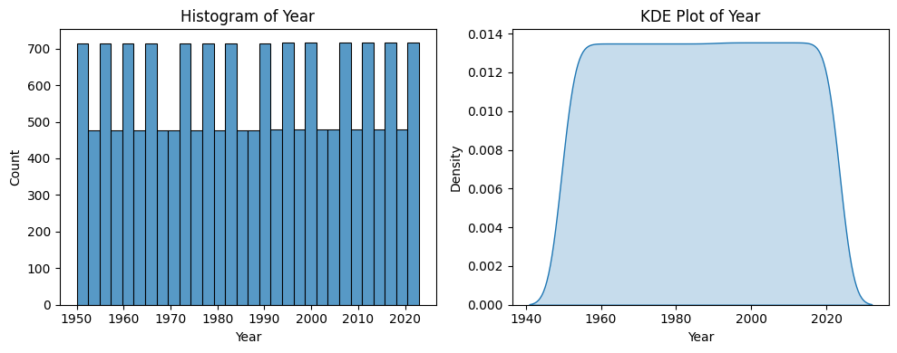

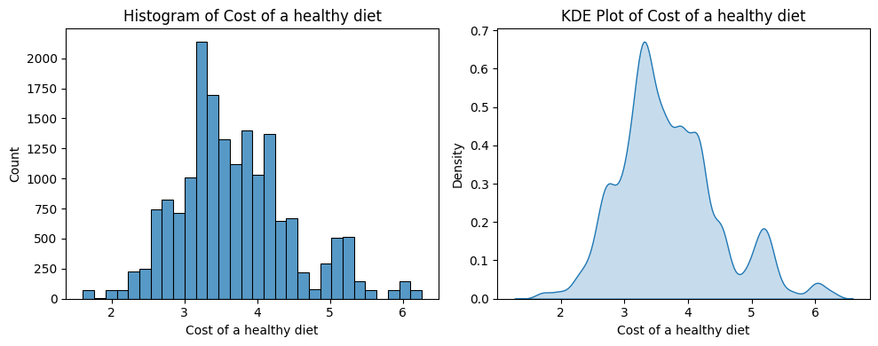

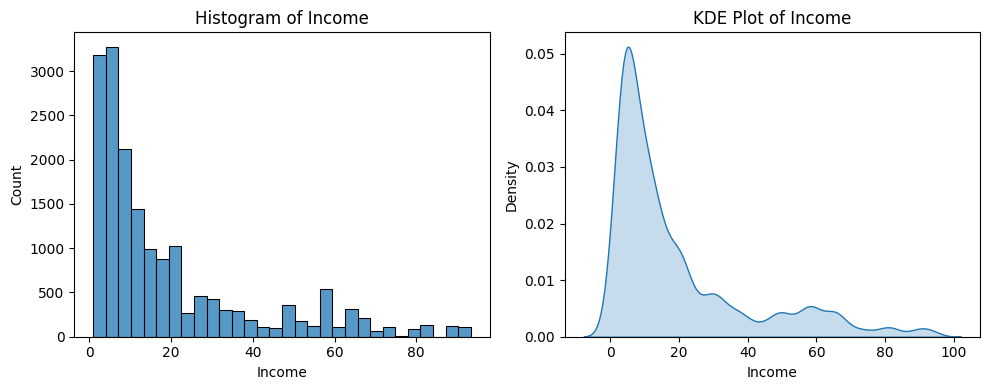

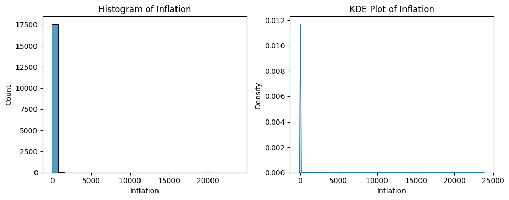

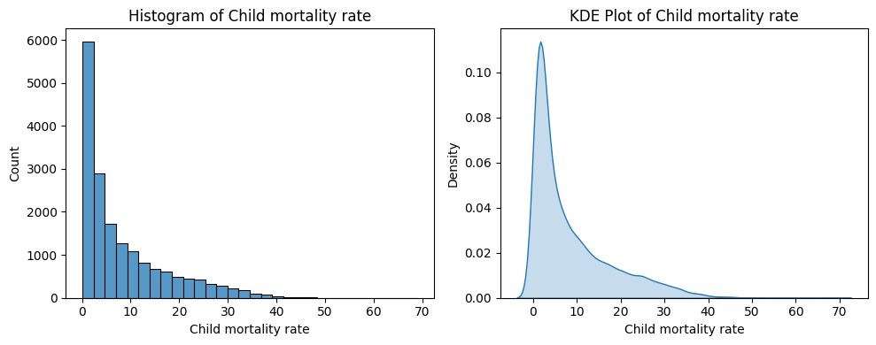

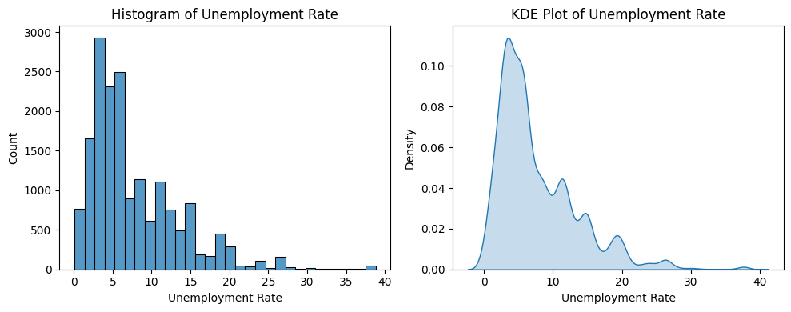

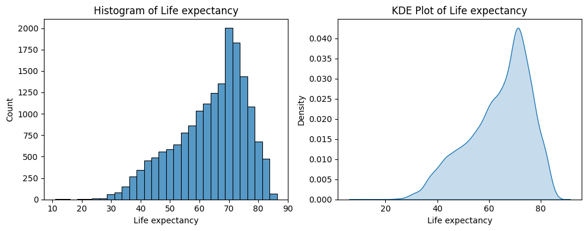

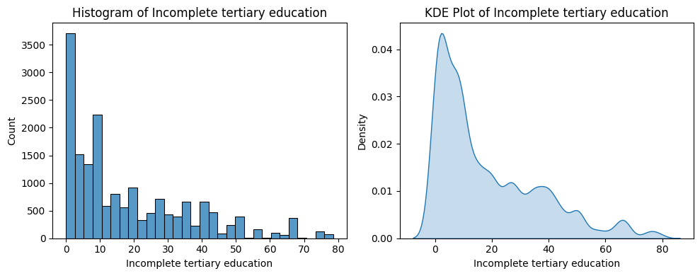

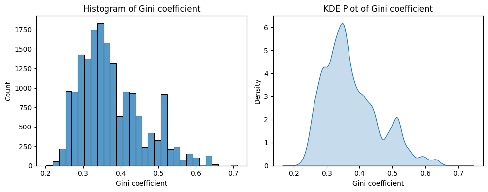

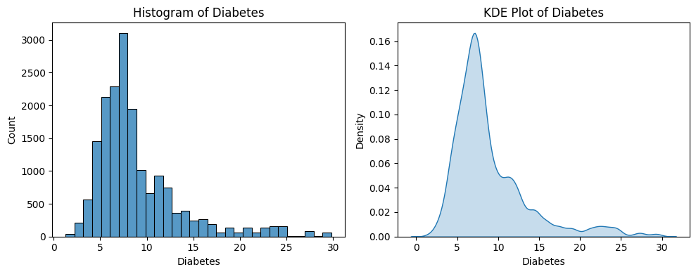

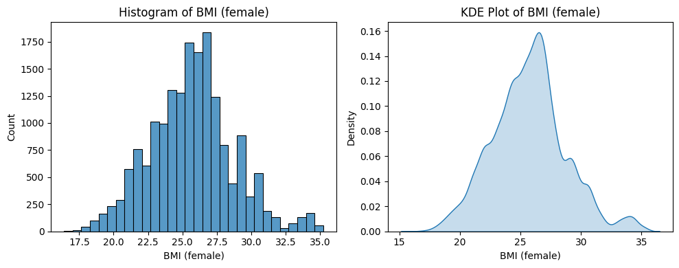

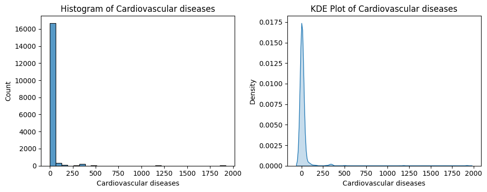

[5 more figures not shown]

```python
# Histogram and Skewness Summary

import pandas as pd
import matplotlib.pyplot as plt
import seaborn as sns

# Replace this with your actual DataFrame
# df = pd.read_csv('your_dataset.csv')

# Identify numeric columns
numeric_cols = df.select_dtypes(include='number').columns

# Calculate skewness
skewness_summary = df[numeric_cols].skew().sort_values(ascending=False)
print("Skewness Summary:")
print(skewness_summary)

# Plot histogram and KDE for each numeric column
for col in numeric_cols:
    plt.figure(figsize=(10, 4))

    plt.subplot(1, 2, 1)
    sns.histplot(df[col].dropna(), bins=30, kde=False)
    plt.title(f'Histogram of {col}')

    plt.subplot(1, 2, 2)
    sns.kdeplot(df[col].dropna(), shade=True)
    plt.title(f'KDE Plot of {col}')

    plt.tight_layout()
    plt.show()
```

## Outliers Detection

The Interquartile Range (IQR) method is used for detecting outliers in this dataset. The reasons as follows:

IQR method is specifically apply for continuous numerical data as most variables in this dataset are continuous numerical, such as Inflation, GDP, CPI etc..

Additionally, IQR method is robust to skewness data, and some of the variables are high skewness, including Inflation, GDP, and CPI. This makes it more suitable than methods like z-score which assume normality.

Since the dataset has very low missing values (< 1.5%), the IQR method can be applied effectively without the need for complex imputation prior to outlier detection. Missing data will not significantly bias the quartile estimates.

The IQR method does not make assumptions for the data normal distribution as most of the variables are skewed, therefore, IQR is appropriate to apply for this dataset.

```python
# Check Outliers

# Iterate only through numeric columns
for col in df.select_dtypes(include='number').columns:
    # Ensure the column has numeric data before proceeding
    if pd.api.types.is_numeric_dtype(df[col]):
        Q1 = df[col].quantile(0.25)
        Q3 = df[col].quantile(0.75)
        IQR = Q3 - Q1
        outliers = df[(df[col] < Q1 - 1.5 * IQR) | (df[col] > Q3 + 1.5 * IQR)]
        print(f"{col}: {len(outliers)} outliers")
    else:
        print(f"Column '{col}' is not numeric, skipping outlier calculation.")
```

```
Year: 0 outliers
Cost of a healthy diet: 434 outliers
Income: 1866 outliers
Inflation: 1801 outliers
Child mortality rate: 845 outliers
Unemployment Rate: 426 outliers
Life expectancy: 89 outliers
Incomplete tertiary education: 208 outliers
Gini coefficient: 370 outliers
Diabetes: 1205 outliers
BMI (female): 508 outliers
Cardiovascular diseases: 2708 outliers
BMI (male): 72 outliers
Sex ratio: 750 outliers
GDP: 2876 outliers
Median age: 52 outliers
CPI: 1494 outliers
```

## Boxplot

Boxplots is a good tool of offering a visual summary of the distribution, skewness, and variability for each numeric variable in the dataset.

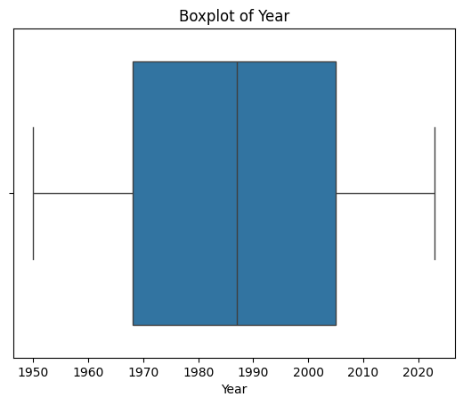

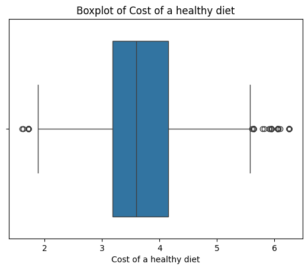

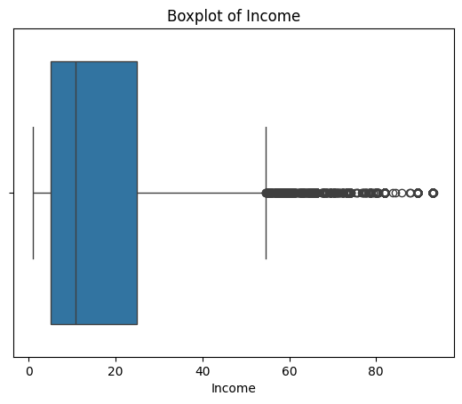

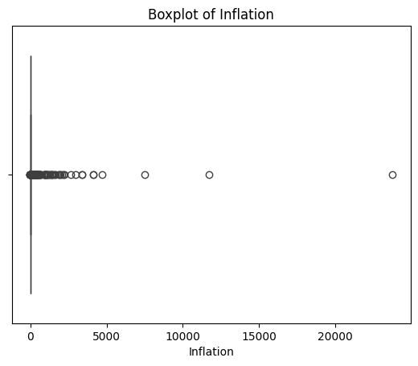

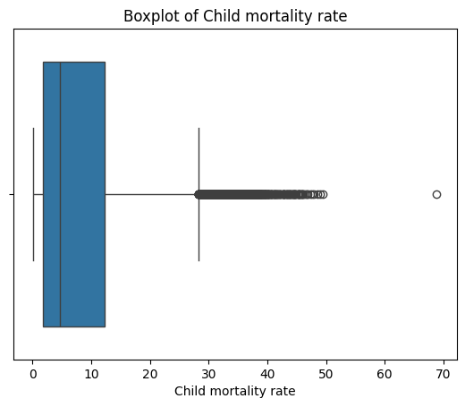

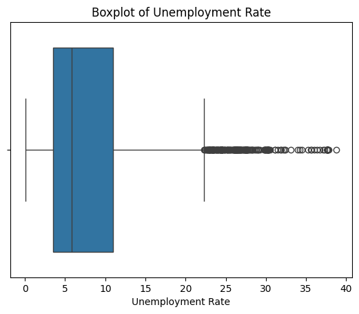

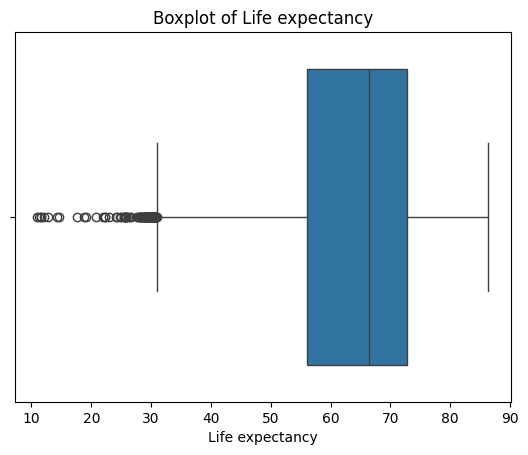

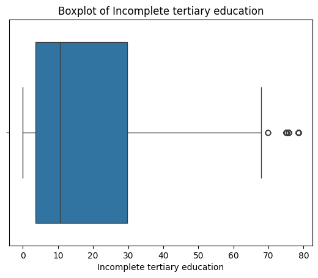

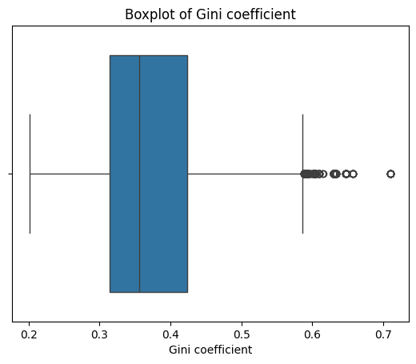

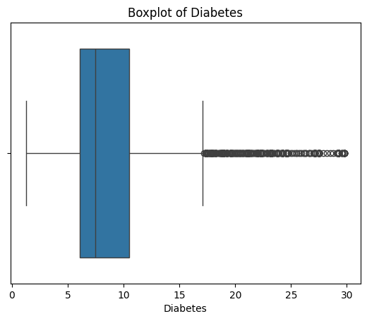

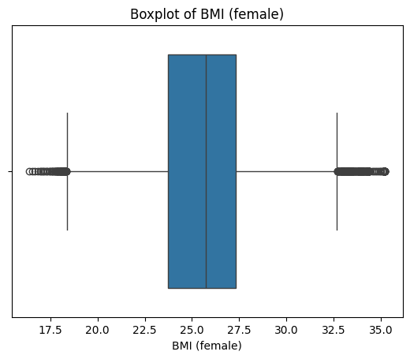

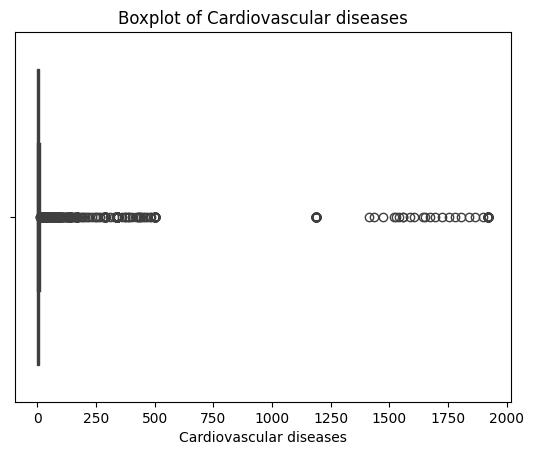

[5 more figures not shown]

```python
# Boxplot

import seaborn as sns
import matplotlib.pyplot as plt

# Loop through all numeric columns to create boxplots
for col in df.select_dtypes(include='number').columns:
    # Get the data for the current numeric column
    column_data = df[col].dropna() # Drop NaN values to avoid potential issues with plotting

    # Check if there is enough data for plotting (at least one non-null value)
    if len(column_data) > 0:
        sns.boxplot(x=column_data)
        plt.title(f"Boxplot of {col}")
        plt.xlabel(col)
        plt.show()
    else:
        print(f"Not enough data to generate boxplot for column: {col}")
```

## Impute missing values with Mean / Median / Mode Imputation for Training Set only

Imputation apply to training set only, avoid data leakage

```python
# Imputation and Train-Test Split

import pandas as pd
import numpy as np
from sklearn.model_selection import train_test_split

# Columns to impute
mean_impute_cols = ['BMI (female)', 'BMI (male)']
median_impute_cols = [
    'CPI', 'Gini coefficient', 'Income', 'Inflation', 'Unemployment Rate', 'Diabetes',
    'Cardiovascular diseases', 'GDP', 'Cost of a healthy diet',
    'Incomplete tertiary education', 'Child mortality rate',
    'Life expectancy', 'Sex ratio', 'Median age'
]

# Containers for all-country data
train_dfs = []
test_dfs = []

# --- Per-country processing ---
for country in df['Country'].unique():
    df_country = df[df['Country'] == country].sort_values('Year').reset_index(drop=True)

    # Skip countries with very few rows
    if len(df_country) < 5:
        continue

    # Time-based train/test split (80% train)
    split_index = int(len(df_country) * 0.8)
    train_country = df_country.iloc[:split_index].copy()
    test_country = df_country.iloc[split_index:].copy()

    # --- Mean imputation ---
    for col in mean_impute_cols:
        if col in train_country.columns:
            mean_val = train_country[col].mean()
            if np.isnan(mean_val):
                mean_val = 0  # Fallback if all values are missing
            train_country[col].fillna(mean_val, inplace=True)
            test_country[col].fillna(mean_val, inplace=True)

    # --- Median imputation with fallback to (median - 1) or -1 ---
    for col in median_impute_cols:
        if col in train_country.columns:
            median_val = train_country[col].median()
            if np.isnan(median_val):
                fill_val = -1
            else:
                fill_val = median_val - 1
            train_country[col].fillna(fill_val, inplace=True)
            test_country[col].fillna(fill_val, inplace=True)

    # Add Country column explicitly before appending
    train_country['Country'] = country
    test_country['Country'] = country

    # Store per-country processed data
    train_dfs.append(train_country)
    test_dfs.append(test_country)

# Combine all countries into unified train/test sets
train_all = pd.concat(train_dfs, ignore_index=True)
test_all = pd.concat(test_dfs, ignore_index=True)

train_all = train_all.set_index(['Country', 'Year'])
test_all = test_all.set_index(['Country', 'Year'])

print(train_all.head())  # should now show Country and Year as index
print(train_all.index.names)  # ['Country', 'Year']

# Final check
print(" Missing values after imputation (Train):")
print(train_all.isnull().sum())

print("\n Missing values after imputation (Test):")
print(test_all.isnull().sum())
```

```
                  Cost of a healthy diet  Income  Inflation  \
Country     Year
Afghanistan 1950                    -1.0    -1.0    9.68342
            1951                    -1.0    -1.0    9.68342
            1952                    -1.0    -1.0    9.68342
            1953                    -1.0    -1.0    9.68342
            1954                    -1.0    -1.0    9.68342

                  Child mortality rate  Unemployment Rate  Life expectancy  \
Country     Year
Afghanistan 1950             41.370100             6.9405          28.1563
            1951             40.799400             6.9405          28.5836
            1952             40.224000             6.9405          29.0138
            1953             39.642300             6.9405          29.4521
            1954             39.158897             6.9405          29.6975

                  Incomplete tertiary education  Gini coefficient  Diabetes  \
Country     Year
Afghanistan 1950                            0.3              -1.0       6.2
            1951                            0.3              -1.0       6.2
            1952                            0.3              -1.0       6.2
            1953                            0.3              -1.0       6.2
            1954                            0.3              -1.0       6.2

                  BMI (female)  Cardiovascular diseases  BMI (male)  \
Country     Year
Afghanistan 1950     21.054667                  3.97278   20.593152
            1951     21.054667                  3.97278   20.593152
            1952     21.054667                  3.97278   20.593152
            1953     21.054667                  3.97278   20.593152
            1954     21.054667                  3.97278   20.593152

                   Sex ratio           GDP  Median age        CPI
Country     Year
Afghanistan 1950   99.845600  4.186536e+10      18.395  75.438705
            1951  101.637560  4.186536e+10      18.370  75.438705
            1952  101.717354  4.186536e+10      18.333  75.438705
            1953  101.792820  4.186536e+10      18.289  75.438705
            1954  101.880760  4.186536e+10      18.239  75.438705
['Country', 'Year']
```

[output cut: 22 more lines]

```
Inflation                        0
Child mortality rate             0
Unemployment Rate                0
Life expectancy                  0
Incomplete tertiary education    0
Gini coefficient                 0
Diabetes                         0
BMI (female)                     0
Cardiovascular diseases          0
BMI (male)                       0
Sex ratio                        0
GDP                              0
Median age                       0
CPI                              0
dtype: int64
```

The above result verify that all missing value have been imputed.

## Spearman Correlation

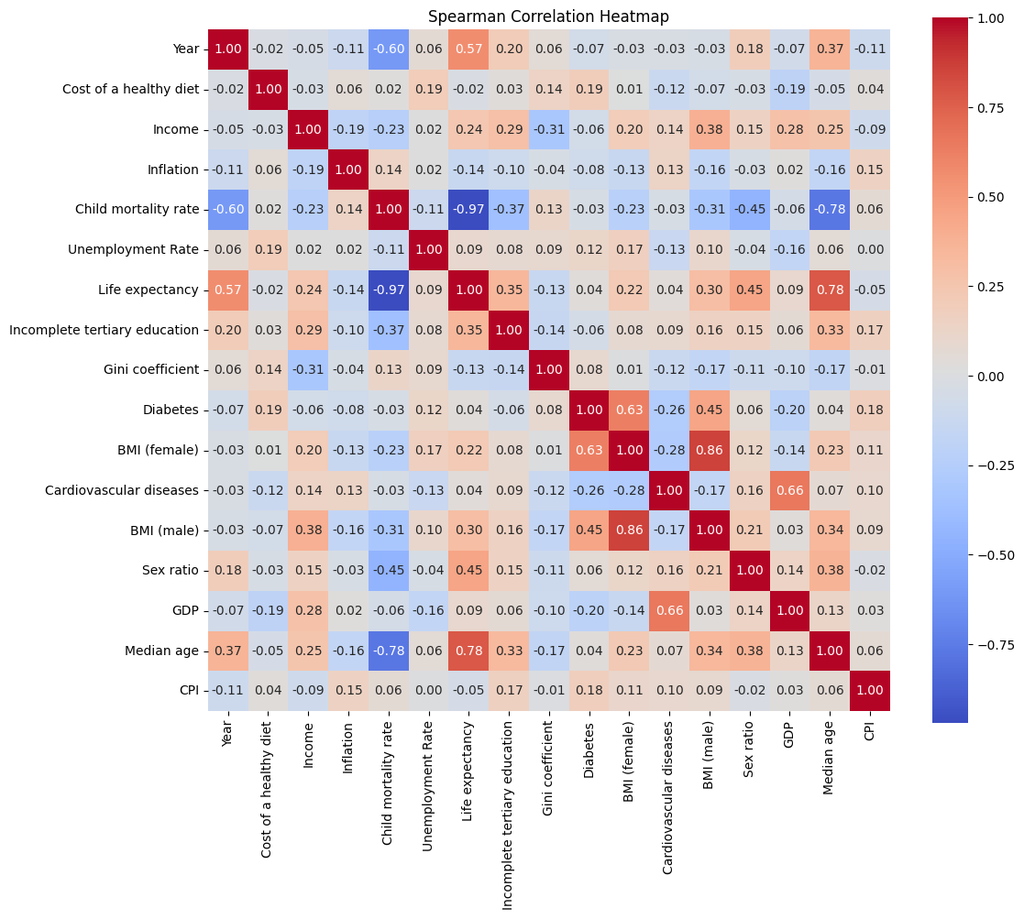

```python
# Spearman Correlation matrix and heatmap

import pandas as pd
import seaborn as sns
import matplotlib.pyplot as plt
import numpy as np # Import numpy for np.number

# Compute correlation matrix - Select only numeric columns
corr_method = 'spearman'
# Select only numeric columns for correlation calculation
df_numeric = df.select_dtypes(include=np.number)
corr_matrix = df_numeric.corr(method=corr_method)

# Plot heatmap
plt.figure(figsize=(12, 10))
sns.heatmap(corr_matrix, annot=True, fmt=".2f", cmap='coolwarm', square=True)
plt.title(f'{corr_method.capitalize()} Correlation Heatmap')
plt.show()
```

## Multicollinearity Check using VIF

Variance Inflation Factor (VIF) measures how much the variance of a regression coefficient is inflated due to multicollinearity among predictor variables. Multicollinearity occurs when predictors are highly correlated with each other, which can lead to unstable coefficient estimates, inflated standard errors, and difficulty in interpreting the individual effects of variables.

VIF with values above 5 or 10 typically indicating problematic multicollinearity. Using VIF helps identify redundant features, guides feature selection, and improves model interpretability by ensuring stable and meaningful coefficient estimates.

For this dataset, which includes continuous numeric variables such as GDP and Income, and uses linear regression models to analyze health outcomes like life expectancy and cardiovascular diseases.

This approach is supported by foundational econometrics and statistical learning literature, including works by Gujarati (2003) and James et al. (2013), as well as applied health research where socioeconomic and health indicators often exhibit correlations.

Overall, incorporating VIF checks enhances the reliability of your regression models, especially when interpreting the impact of predictors.

```python
# VIF Test for checking multicollinarity

from statsmodels.stats.outliers_influence import variance_inflation_factor
from statsmodels.tools.tools import add_constant
import pandas as pd

# Select the features for VIF calculation (excluding target variables)
vif_features = [
    'Income', 'GDP', 'CPI', 'Sex ratio', 'BMI (female)', 'Cost of a healthy diet',
    'Inflation', 'Incomplete tertiary education', 'Gini coefficient', 'Median age',
    'BMI (male)', 'Unemployment Rate', 'Child mortality rate'
]

# Drop rows with missing values
vif_data = train_all[vif_features].dropna()

# Add constant term for intercept
vif_data_const = add_constant(vif_data)

# Calculate VIF
vif_df = pd.DataFrame()
vif_df["Feature"] = vif_data_const.columns
vif_df["VIF"] = [variance_inflation_factor(vif_data_const.values, i) for i in range(vif_data_const.shape[1])]

# Display VIF values
print("\nVariance Inflation Factors:")
print(vif_df)
```

```
Variance Inflation Factors:
                          Feature       VIF
0                           const  0.000000
1                          Income  1.338307
2                             GDP  1.024624
3                             CPI  1.003511
4                       Sex ratio  1.126552
5                    BMI (female)  6.641593
6          Cost of a healthy diet  1.246448
7                       Inflation  1.001940
8   Incomplete tertiary education  1.095969
9                Gini coefficient  1.272552
10                     Median age  1.569114
11                     BMI (male)  7.140645
12              Unemployment Rate  1.083354
13           Child mortality rate  1.567488
```

```python
# Combine variable BMI(female) and BMI(male) by using their average for dataset

# Create combined BMI feature
df['BMI_avg'] = (df['BMI (female)'] + df['BMI (male)']) / 2

# Drop the original columns
df.drop(['BMI (female)', 'BMI (male)'], axis=1, inplace=True)
```

```python
# Combine variable BMI(female) and BMI(male) by using their average for train set and test set

# Create combined BMI feature for train and test set
train_all['BMI_avg'] = (train_all['BMI (female)'] + train_all['BMI (male)']) / 2
test_all['BMI_avg'] = (test_all['BMI (female)'] + test_all['BMI (male)']) / 2

# Drop the original columns
train_all.drop(['BMI (female)', 'BMI (male)'], axis=1, inplace=True)
test_all.drop(['BMI (female)', 'BMI (male)'], axis=1, inplace=True)

# Check first few column
print("Train Set")
print(train_all.head())
print("Test Set")
print(test_all.head())
```

```
Train Set
                  Cost of a healthy diet  Income  Inflation  \
Country     Year
Afghanistan 1950                    -1.0    -1.0    9.68342
            1951                    -1.0    -1.0    9.68342
            1952                    -1.0    -1.0    9.68342
            1953                    -1.0    -1.0    9.68342
            1954                    -1.0    -1.0    9.68342

                  Child mortality rate  Unemployment Rate  Life expectancy  \
Country     Year
Afghanistan 1950             41.370100             6.9405          28.1563
            1951             40.799400             6.9405          28.5836
            1952             40.224000             6.9405          29.0138
            1953             39.642300             6.9405          29.4521
            1954             39.158897             6.9405          29.6975

                  Incomplete tertiary education  Gini coefficient  Diabetes  \
Country     Year
Afghanistan 1950                            0.3              -1.0       6.2
            1951                            0.3              -1.0       6.2
            1952                            0.3              -1.0       6.2
            1953                            0.3              -1.0       6.2
            1954                            0.3              -1.0       6.2

                  Cardiovascular diseases   Sex ratio           GDP  \
Country     Year
Afghanistan 1950                  3.97278   99.845600  4.186536e+10
            1951                  3.97278  101.637560  4.186536e+10
            1952                  3.97278  101.717354  4.186536e+10
            1953                  3.97278  101.792820  4.186536e+10
            1954                  3.97278  101.880760  4.186536e+10

                  Median age        CPI    BMI_avg
Country     Year
Afghanistan 1950      18.395  75.438705  20.823909
            1951      18.370  75.438705  20.823909
            1952      18.333  75.438705  20.823909
            1953      18.289  75.438705  20.823909
            1954      18.239  75.438705  20.823909
```

[output cut: 25 more lines]

```
                  Cardiovascular diseases   Sex ratio           GDP  \
Country     Year
Afghanistan 2009                 5.004783  105.540780  7.045116e+10
            2010                 5.041143  105.446550  8.056966e+10
            2011                 5.226536  105.328636  8.091317e+10
            2012                 5.342172  105.202095  9.123145e+10
            2013                 5.491725  105.091530  9.634110e+10

                  Median age         CPI    BMI_avg
Country     Year
Afghanistan 2009      14.448   97.867910  22.721053
            2010      14.608  100.000000  22.824260
            2011      14.776  111.804184  22.928318
            2012      14.947  119.005730  23.033418
            2013      15.124  127.795220  23.139556
```

```python
# VIF Test again after combined a new variable BMI_avg

# VIF Test for checking multicollinarity

# Select the features for VIF calculation (excluding target variables)
vif_features = [
    'Income', 'GDP', 'CPI', 'Sex ratio', 'BMI_avg', 'Cost of a healthy diet',
    'Inflation', 'Incomplete tertiary education', 'Gini coefficient', 'Median age',
    'Unemployment Rate', 'Child mortality rate'
]

# Drop rows with missing values
vif_data = train_all[vif_features].dropna()

# Add constant term for intercept
vif_data_const = add_constant(vif_data)

# Calculate VIF
vif_df = pd.DataFrame()
vif_df["Feature"] = vif_data_const.columns
vif_df["VIF"] = [variance_inflation_factor(vif_data_const.values, i) for i in range(vif_data_const.shape[1])]

# Display VIF values
print("\nVariance Inflation Factors:")
print(vif_df)
```

```
Variance Inflation Factors:
                          Feature       VIF
0                           const  0.000000
1                          Income  1.151946
2                             GDP  1.021710
3                             CPI  1.003505
4                       Sex ratio  1.123716
5                         BMI_avg  1.099278
6          Cost of a healthy diet  1.246317
7                       Inflation  1.001889
8   Incomplete tertiary education  1.089855
9                Gini coefficient  1.264301
10                     Median age  1.521325
11              Unemployment Rate  1.067065
12           Child mortality rate  1.559535
```

```python
# Final check
print(" Missing values after imputation (Train):")
print(train_all.isnull().sum())
```

```
 Missing values after imputation (Train):
Cost of a healthy diet           0
Income                           0
Inflation                        0
Child mortality rate             0
Unemployment Rate                0
Life expectancy                  0
Incomplete tertiary education    0
Gini coefficient                 0
Diabetes                         0
Cardiovascular diseases          0
Sex ratio                        0
GDP                              0
Median age                       0
CPI                              0
BMI_avg                          0
dtype: int64
```

## Handling Outliers - Winsorization and Yeo-Johnson Transformation

1. Winsorization

Winsorization is a statistical technique that Capping extreme values at chosen percentiles to minimize the influence of outliers on data analysis, preserving the overall structure of the dataset, can be retains dataset integrity while reducing distortion.

It involves setting a threshold (e.g., the 5th and 95th percentiles) and replacing any values below the lower threshold with the value at that threshold, and any values above the upper threshold with the value at that threshold.

Several studies support Winsorization. Weichle (2023) investigated how different methods for handling outliers and influential observations impact the calculation of medical costs in a dataset and successfully apply Winsorization to cap extreme cost values at the 5th and 95th percentiles to reduce the influence of extreme outliers Balia & Jones (2008): In colon cancer cost data, using Winsorization at 5% (5th–95th percentile) replaced 384 outliers, yielding a more consistent average cost without removing data Carrascosa (2025): Provides a “complete guide” to handling outliers. Hoaglin & Iglewicz (1987) or Rousseeuw & Hubert (1991), both seminal works that recommend Winsorization in robust statistics.

Lu et al. (2024): Winsorization before RNA-seq analysis considerably reduced false positives, improving model performance, and was recommended at 95%

Pachter (2024) investigate the effective percentage of capping applying Winsorization, 93%, 95% and 987% are being tested. Concluded that use 95% for applying Winsorization is the best.

2. Yeo-Johnson Transformation

Yeo-Johnson transformation is used after handled outliers by Winsorization. This dataset contains multiple continuous numeric variables (such as income, BMI, GDP, and health-related indicators) that show skewed distributions. Skewness causes coeficient bias, poor model fit, inefficient forecast and negatively impact many modeling techniques by violating assumptions such as ARIMA, linear regression and part of Prophet, that assume the features are normal distributed, therefore handle outliers is essential for generating reliable and stable predictions.

Yeo-Johnson transformation is used in this dataset. The Yeo-Johnson transformation is a statistical technique used to normalize data to make it more symmetrical and reduce skewness. The reason of using Yeo-Johnson because this method appropriate to work with continuous numeric varibles as this dataset primarily composed of continuous numerical features such as GDP, BMI, income, and other health indicators, exactly match the type of data Yeo-Johnson is designed to handle. Additionally, Yeo-Johnson transformation can handle positive, negative and zero values, which is suitable to handle this dataset that contains negative and zero values, such as inflation. Furthermore, Yeo-Johnson improve normality and reduce skewness, which appropriate to use as the assumption of ARIMA, Prophet, linear regression require normal distributed residual, which enhances model validity and stablility.

Compatible with integer or float data Yeo-Johnson can be applied to both integer and float types (e.g., "Median age"), eliminating the need for manual type conversion.

Not applicable to categorical variables Your dataset includes one categorical feature (e.g., "Country"), which should be excluded from this transformation. Yeo-Johnson is only suitable for numeric features.

One of the categorical variable (e.g., Country) should be excluded This transformation is not meant for categorical data — but that's fine. Just apply it only to your numeric columns.

Several studies have demonstrated the effectiveness of the Yeo-Johnson transformation in addressing these issues. For example, Zhang et al. (2018) applied the Yeo-Johnson transformation to normalize skewed biomarker and health outcome data prior to predictive modeling. Min et al. (2020) used the method to correct skewness in economic variables such as income and expenditure before conducting regression analysis. Similarly, Wang et al. (2019) employed Yeo-Johnson to transform environmental pollutant data, including values that were zero or negative, leading to improved model fit and interpretability. These studies provide strong evidence that Yeo-Johnson is a robust and versatile transformation suitable for datasets like yours.

Yeo-Johnson transformation benefits ARIMA and Prophet by improving normality and variance stability, helping assumptions and model fit.

```python
# Winsorization and Yeo_Johnson

import numpy as np
import pandas as pd
from sklearn.preprocessing import PowerTransformer

#  Additional Assign index: Country and Year
#df = df.set_index(['Country', 'Year'])

# List columns to transform (excluding only identifiers)
exclude_cols = ['Country', 'Year', 'Life expectancy', 'Diabetes', 'Cardiovascular diseases']
target_cols = ['Life expectancy', 'Diabetes', 'Cardiovascular diseases']
numeric_cols = [
    col for col in train_all.columns
    if col not in exclude_cols
]

# --- Step 1: Winsorization at 5‑95% ---
def winsorize_df(df, cols, lower_q=0.05, upper_q=0.95):
    df_w = train_all.copy()
    limits = {}
    for col in cols:
        lower = train_all[col].quantile(lower_q)
        upper = train_all[col].quantile(upper_q)
        limits[col] = (lower, upper)
        df_w[col] = np.clip(df[col], lower, upper)
    return df_w, limits

# Apply Winsorization to train set
train_df_w, limits = winsorize_df(train_all, numeric_cols, 0.05, 0.95)

# Apply same limits to test set
test_df_w = test_all.copy()
for col, (low, high) in limits.items():
    test_df_w[col] = np.clip(test_all[col], low, high)

# --- Step 2: Yeo‑Johnson Transformation ---
pt = PowerTransformer(method='yeo-johnson', standardize=False)

# Fit on winsorized train data
train_df_transformed = train_df_w.copy()
train_df_transformed[numeric_cols] = pt.fit_transform(train_df_w[numeric_cols])

# Apply to test data
test_df_transformed = test_df_w.copy()
test_df_transformed[numeric_cols] = pt.transform(test_df_w[numeric_cols])

# --- Preview results ---
print("=== Train Transformed Sample ===")
print(train_df_transformed[target_cols + [c for c in numeric_cols if c not in target_cols]].head())
print("\n=== Test Transformed Sample ===")
print(test_df_transformed[target_cols + [c for c in numeric_cols if c not in target_cols]].head())

# combine train and test
# --- Step 3: Combine Transformed Train and Test Data ---
df_transformed = pd.concat([train_df_transformed, test_df_transformed], axis=0)

print("\n✅ Combined Transformed DataFrame:")
print(df_transformed.head())
```

```
=== Train Transformed Sample ===
                  Life expectancy  Diabetes  Cardiovascular diseases  \
Country     Year
Afghanistan 1950          28.1563       6.2                  3.97278
            1951          28.5836       6.2                  3.97278
            1952          29.0138       6.2                  3.97278
            1953          29.4521       6.2                  3.97278
            1954          29.6975       6.2                  3.97278

                  Cost of a healthy diet    Income  Inflation  \
Country     Year
Afghanistan 1950                0.871262  1.069802   2.119237
            1951                0.871262  1.069802   2.119237
            1952                0.871262  1.069802   2.119237
            1953                0.871262  1.069802   2.119237
            1954                0.871262  1.069802   2.119237

                  Child mortality rate  Unemployment Rate  \
Country     Year
Afghanistan 1950              3.288735           1.968604
            1951              3.288735           1.968604
            1952              3.288735           1.968604
            1953              3.288735           1.968604
            1954              3.288735           1.968604

                  Incomplete tertiary education  Gini coefficient  Sex ratio  \
Country     Year
Afghanistan 1950                        0.26709          0.140308   0.268828
            1951                        0.26709          0.140308   0.268828
            1952                        0.26709          0.140308   0.268828
            1953                        0.26709          0.140308   0.268828
            1954                        0.26709          0.140308   0.268828

                        GDP  Median age       CPI    BMI_avg
Country     Year
Afghanistan 1950  26.976456    0.704301  9.172623  26.023944
            1951  26.976456    0.704280  9.172623  26.023944
            1952  26.976456    0.704250  9.172623  26.023944
            1953  26.976456    0.704213  9.172623  26.023944
            1954  26.976456    0.704172  9.172623  26.023944
```

[output cut: 67 more lines]

```
                  Cardiovascular diseases  Sex ratio        GDP  Median age  \
Country     Year
Afghanistan 1950                  3.97278   0.268828  26.976456    0.704301
            1951                  3.97278   0.268828  26.976456    0.704280
            1952                  3.97278   0.268828  26.976456    0.704250
            1953                  3.97278   0.268828  26.976456    0.704213
            1954                  3.97278   0.268828  26.976456    0.704172

                       CPI    BMI_avg
Country     Year
Afghanistan 1950  9.172623  26.023944
            1951  9.172623  26.023944
            1952  9.172623  26.023944
            1953  9.172623  26.023944
            1954  9.172623  26.023944
```

```python
# Verify Index
print(train_df_transformed.index.names)
```

```
['Country', 'Year']
```

# Lag Feature

Lag features are values from previous time steps used as predictors to forecast current or future values.

It suitable to apply for RQ3 forecasting life expectancy, diabetes, or heart disease over time. Lag features will help Prophet and regression models capture dependencies across years more effectively. ARIMA and Random Forest will create lag internally.

Lag is important because it helps to identify patterns and relationships between past and present data points. Time series models, such as ARIMA, heavily rely on lag to capture autocorrelations (the correlation between observations at different time lags) in the data.

Key reasons why lag is essential:

Autocorrelation Detection: Lag enables analysts to understand how current data points are related to previous ones. If there is a significant autocorrelation at a particular lag, it suggests that past values can be used to predict future values. Feature Creation: In machine learning models for time series forecasting, lagged variables are often used as features. These features represent the values of the time series at previous time steps, allowing the model to learn patterns over time. Trend Identification: By observing how values change across different lags, trends and seasonality can be identified. For instance, a consistent increase in lagged values may indicate an upward trend.

In ARIMA, the model forecasts a time series based on the linear relationship between an observation and a number of lagged observations.

Several prior studies proof that Lag Feature is a crucial technique for time series modeling, such as ARIMA, Prophet and Random Forest.

Debón et al. (2017) used lagged mortality rates to forecast life expectancy in European countries. Wang et al. (2019) – used lagged environmental and health variables to predict life expectancy and disease incidence in China. And Chakraborty et al. (2020) – used lagged economic indicators to predict diabetes trends in India.

```python
# Lag Feature

# === STEP 1: Combine transformed train and test sets ===
df_transformed = pd.concat([train_df_transformed, test_df_transformed], axis=0)

# If index is already set, reset it to ensure 'Country' and 'Year' are columns
if 'Country' not in df_transformed.columns or 'Year' not in df_transformed.columns:
    df_transformed = df_transformed.reset_index()

# Set MultiIndex for lagging
df_transformed = df_transformed.set_index(['Country', 'Year']).sort_index()

# === STEP 2: Define target and predictor columns ===
target_cols = ['Life expectancy', 'Cardiovascular diseases', 'Diabetes']
predictors = [col for col in df_transformed.columns if col not in target_cols and col != 'lagged']

# === STEP 3: Create lagged features ===
def create_lag_features(df, cols, lags=[1, 2, 3]):
    df_lag = df.copy()
    for col in cols:
        for lag in lags:
            df_lag[f'{col}_lag{lag}'] = df.groupby(level='Country')[col].shift(lag)
    return df_lag

df_lagged = create_lag_features(df_transformed, predictors)

# === STEP 4: Tag lagged vs. unlagged rows ===
df_transformed['lagged'] = False
df_lagged['lagged'] = True

# === STEP 5: Combine both to retain full year coverage ===
df_combined = pd.concat([df_transformed, df_lagged])
df_combined = df_combined.reset_index()
df_combined = df_combined.drop_duplicates(subset=['Country', 'Year'], keep='last')
df_combined = df_combined.set_index(['Country', 'Year']).sort_index()

# === STEP 6: Impute missing values caused by lagging ===
df_combined = (
    df_combined
    .reset_index()
    .groupby('Country', group_keys=False)
    .apply(lambda x: x.sort_values('Year').ffill().bfill())
    .reset_index(drop=True)
    .set_index(['Country', 'Year']).sort_index()
)

# === STEP 7: Final dataset for modeling ===
df_combined_with_country = df_combined.reset_index()

# === STEP 8: Preview sample of lagged features ===
lag_cols = [f'{col}_lag{lag}' for col in predictors for lag in [1, 2, 3]]
print(" Combined Dataset (1950–2023) with Lag Features + Imputed NaNs")
print(df_combined_with_country[['Country', 'Year'] + lag_cols].head(10))

# export and download file
df_combined_with_country.to_csv("df_combined_with_country.csv", index=False)
df_lagged.to_csv("df_lagged.csv", index=False)

from google.colab import files
files.download("df_combined_with_country.csv")
files.download("df_lagged.csv")
```

```
 Combined Dataset (1950–2023) with Lag Features + Imputed NaNs
       Country  Year  Cost of a healthy diet_lag1  \
0  Afghanistan  1950                     0.871262
1  Afghanistan  1951                     0.871262
2  Afghanistan  1952                     0.871262
3  Afghanistan  1953                     0.871262
4  Afghanistan  1954                     0.871262
5  Afghanistan  1955                     0.871262
6  Afghanistan  1956                     0.871262
7  Afghanistan  1957                     0.871262
8  Afghanistan  1958                     0.871262
9  Afghanistan  1959                     0.871262

   Cost of a healthy diet_lag2  Cost of a healthy diet_lag3  Income_lag1  \
0                     0.871262                     0.871262     1.069802
```

[output cut: 47 more lines]

```python
# lag feature - REVISED - lag after train test set

import pandas as pd

# === STEP 1: Ensure 'Country' and 'Year' are columns (if set as index)
if train_df_transformed.index.names == ['Country', 'Year']:
    train_df_transformed = train_df_transformed.reset_index()

if test_df_transformed.index.names == ['Country', 'Year']:
    test_df_transformed = test_df_transformed.reset_index()

# === STEP 2: Set MultiIndex for lagging
train_df_transformed = train_df_transformed.set_index(['Country', 'Year']).sort_index()
test_df_transformed = test_df_transformed.set_index(['Country', 'Year']).sort_index()

# === STEP 3: Define target and predictor columns
target_cols = ['Life expectancy', 'Cardiovascular diseases', 'Diabetes']
predictors = [col for col in train_df_transformed.columns if col not in target_cols and col != 'lagged']

# === STEP 4: Function to create lag features (only on train set)
def create_lag_features(df, cols, lags=[1, 2, 3]):
    df_lag = df.copy()
    for col in cols:
        for lag in lags:
            df_lag[f'{col}_lag{lag}'] = df_lag.groupby(level='Country')[col].shift(lag)
    return df_lag

train_lagged = create_lag_features(train_df_transformed, predictors)

# === STEP 5: Impute missing lag values in training set (from early years like 1950–1952)
train_lagged = (
    train_lagged
    .reset_index()
    .groupby('Country', group_keys=False)
    .apply(lambda x: x.sort_values('Year').ffill().bfill())
    .reset_index(drop=True)
    .set_index(['Country', 'Year']).sort_index()
)

# === STEP 6: Add a flag for lagged data (optional, useful for debugging)
train_lagged['lagged'] = True
test_df_transformed['lagged'] = False

# === STEP 7: Combine train and test into full set for modeling/prediction
df_combined = pd.concat([train_lagged, test_df_transformed])
df_combined = df_combined.reset_index()
df_combined = df_combined.sort_values(['Country', 'Year']).drop_duplicates(subset=['Country', 'Year'], keep='last')
df_combined = df_combined.set_index(['Country', 'Year']).sort_index()

# === STEP 8: Final safety fill to ensure no missing cells (optional)
df_combined = (
    df_combined
    .reset_index()
    .groupby('Country', group_keys=False)
    .apply(lambda x: x.sort_values('Year').ffill().bfill())
    .reset_index(drop=True)
    .set_index(['Country', 'Year']).sort_index()
)

# === STEP 9: Reset index for modeling
df_combined_with_country = df_combined.reset_index()

# === STEP 10: Check sample of lag features
lag_cols = [f'{col}_lag{lag}' for col in predictors for lag in [1, 2, 3]]
print("\n✅ Final Combined Dataset (1950–2023) with Lag Features — No Missing Values:")
print(df_combined_with_country[['Country', 'Year'] + lag_cols].head(10))

# export and download file
df_combined_with_country.to_csv("df_combined_with_country.csv", index=False)
df_combined.to_csv("df_combined.csv", index=False)

from google.colab import files
files.download("df_combined_with_country.csv")
files.download("df_combined.csv")
```

```
✅ Final Combined Dataset (1950–2023) with Lag Features — No Missing Values:
       Country  Year  Cost of a healthy diet_lag1  \
0  Afghanistan  1950                     0.871262
1  Afghanistan  1951                     0.871262
2  Afghanistan  1952                     0.871262
3  Afghanistan  1953                     0.871262
4  Afghanistan  1954                     0.871262
5  Afghanistan  1955                     0.871262
6  Afghanistan  1956                     0.871262
7  Afghanistan  1957                     0.871262
8  Afghanistan  1958                     0.871262
9  Afghanistan  1959                     0.871262

   Cost of a healthy diet_lag2  Cost of a healthy diet_lag3  Income_lag1  \
0                     0.871262                     0.871262     1.069802
```

[output cut: 47 more lines]

## Restore Index - Country and Year

```python
## restore Country and year for df_transformed
# Restore index — only if not already set
if 'Country' not in df_transformed.index.names or 'Year' not in df_transformed.index.names:
    df_transformed = df_transformed.set_index(['Country', 'Year'])

# Optional: sort for time-aware operations
df_transformed = df_transformed.sort_index()

# Preview index structure
print("✅ Index restored — here’s a sample:")
print(df_transformed.head())
```

```
✅ Index restored — here’s a sample:
                  Cost of a healthy diet    Income  Inflation  \
Country     Year
Afghanistan 1950                0.871262  1.069802   2.119237
            1951                0.871262  1.069802   2.119237
            1952                0.871262  1.069802   2.119237
            1953                0.871262  1.069802   2.119237
            1954                0.871262  1.069802   2.119237

                  Child mortality rate  Unemployment Rate  Life expectancy  \
Country     Year
Afghanistan 1950              3.288735           1.968604          28.1563
            1951              3.288735           1.968604          28.5836
            1952              3.288735           1.968604          29.0138
            1953              3.288735           1.968604          29.4521
            1954              3.288735           1.968604          29.6975

                  Incomplete tertiary education  Gini coefficient  Diabetes  \
Country     Year
Afghanistan 1950                        0.26709          0.140308       6.2
            1951                        0.26709          0.140308       6.2
            1952                        0.26709          0.140308       6.2
            1953                        0.26709          0.140308       6.2
            1954                        0.26709          0.140308       6.2

                  Cardiovascular diseases  Sex ratio        GDP  Median age  \
Country     Year
Afghanistan 1950                  3.97278   0.268828  26.976456    0.704301
            1951                  3.97278   0.268828  26.976456    0.704280
            1952                  3.97278   0.268828  26.976456    0.704250
            1953                  3.97278   0.268828  26.976456    0.704213
            1954                  3.97278   0.268828  26.976456    0.704172

                       CPI    BMI_avg  lagged
Country     Year
Afghanistan 1950  9.172623  26.023944   False
            1951  9.172623  26.023944   False
            1952  9.172623  26.023944   False
            1953  9.172623  26.023944   False
            1954  9.172623  26.023944   False
```

# Identify the Best Feature Selection Method and The Best Number of Features for Modeling

1. LASSO (Least Absolute Shrinkage and Selection Operator)
2. RFE (Recursive Feature Elimination)
3. Forward Selection
4. Random Forest Each method selects features based on different principles, and for each method, the code evaluates models using a different number of features—starting from 1 up to a maximum (e.g., 15). For each configuration (method + number of features), the model’s performance is assessed using TimeSeriesSplit cross-validation and Root Mean Squared Error (RMSE) as the evaluation metric. The process is repeated for each of your target variables separately. The method and feature count with the lowest RMSE is considered optimal for that target.